# ggplot notes

# univariate - one variable

## categorical

examine the distribution of the `cut` of a diamond

```r
table(dsmall$cut)
```

```
##
##      Fair      Good Very Good   Premium     Ideal
##        27        83       226       277       387
```

turn this into a bar chart

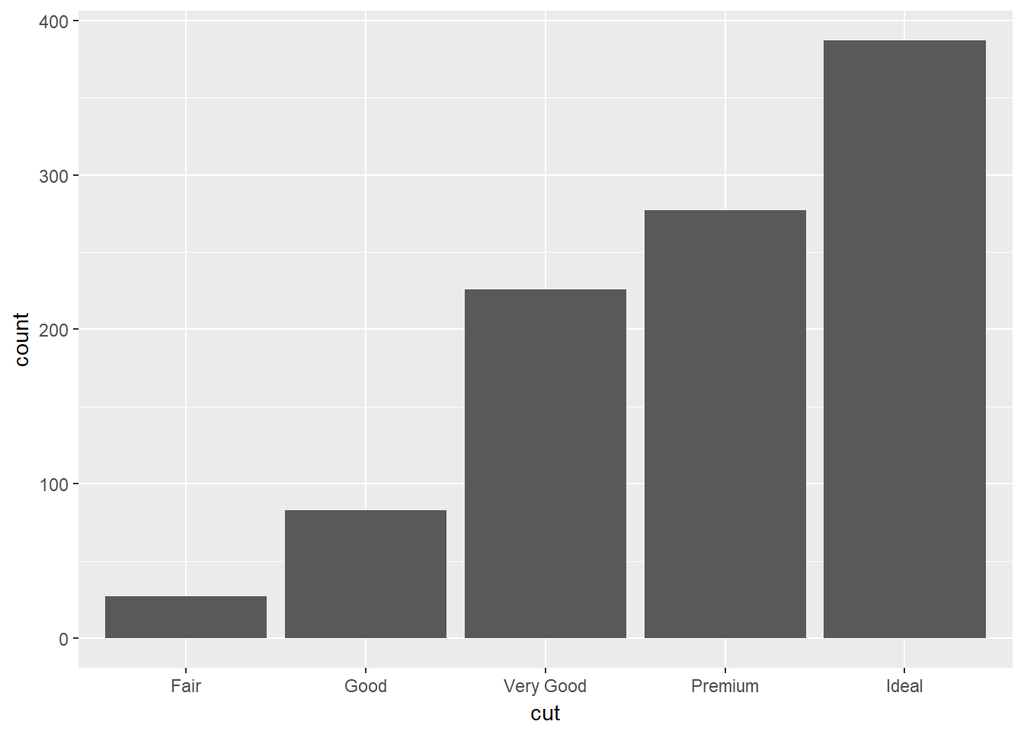

```r
ggplot(dsmall, aes(x=cut)) + geom_bar()
```

what if I forgot to put the `()` after the geometry?

```r
ggplot(dsmall, aes(x=cut)) + geom_bar
```

```
## Error: Don't know how to add geom_bar to a plot
```

> Interlude: Get rid of bars that show missing data.

Make some missing data in `dsmall` data set - create a copy for demo purposes

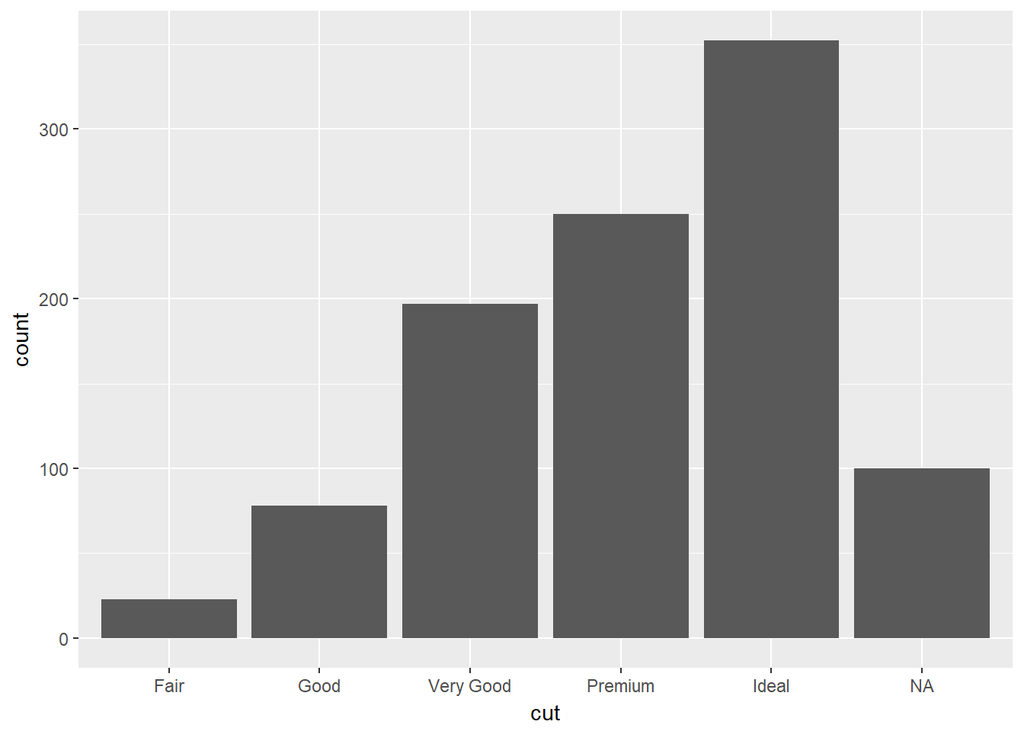

```r
dsmall2 <- dsmall
# random sample of 100 rows, set cut to missing
dsmall2$cut[sample(nrow(dsmall), 100)] <- NA

ggplot(dsmall2, aes(x=cut)) + geom_bar()
```

> option 1 to remove that bar: subset the data to be plotted to remove NA’s

take dsmall, and only the rows where `cut` is not missing (`!is.na()`) the `!` negates `is.na()`, so TRUE means the value for `cut` IS NOT missing.

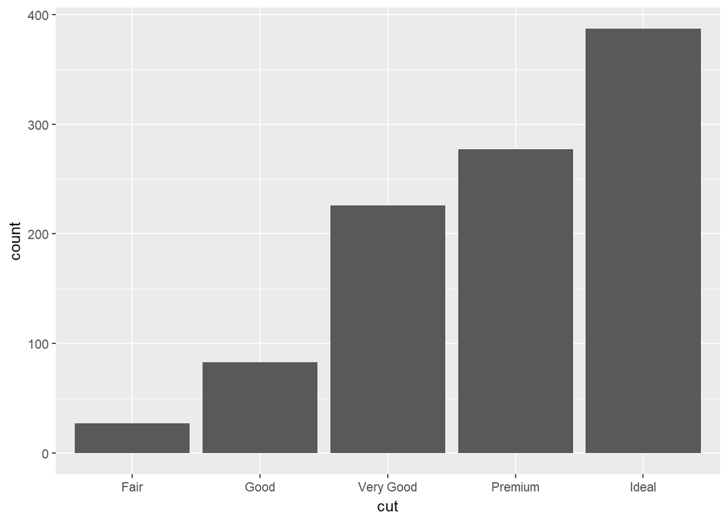

```r
temp.data.to.plot <- dsmall[!is.na(dsmall$cut),]
ggplot(temp.data.to.plot, aes(x=cut)) + geom_bar()
```

pie charts can be done, but not recommended without further modification. See the full data viz tutorial for more info.

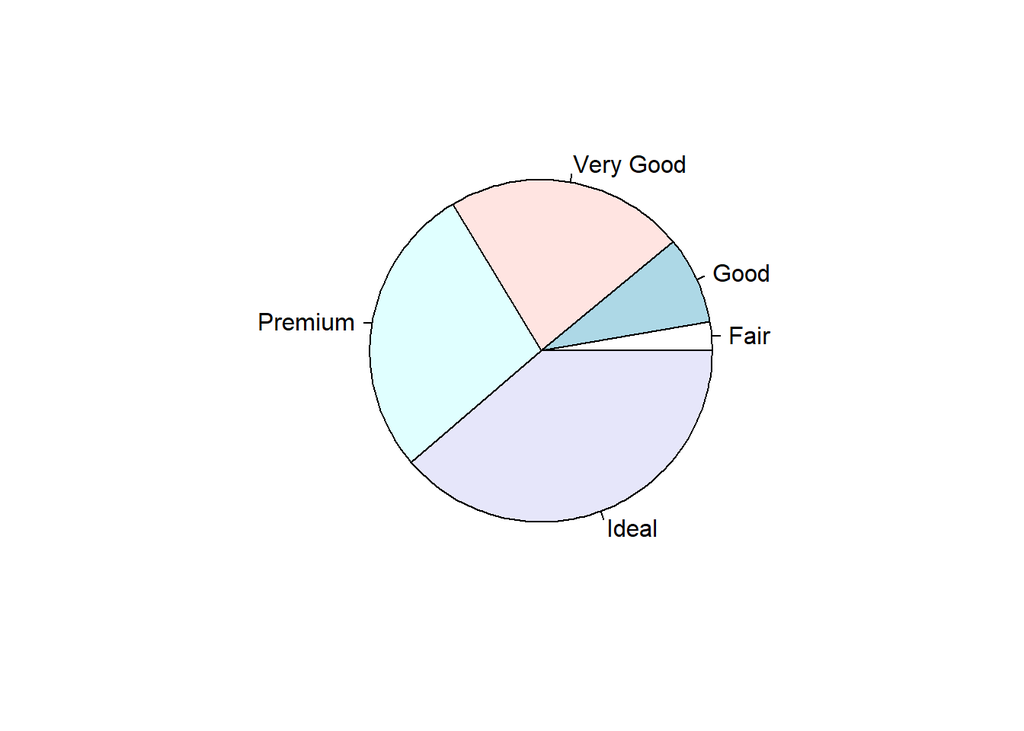

```r
pie(table(dsmall$cut))
```

## continuous

examine the distribution of the depth of a diamond

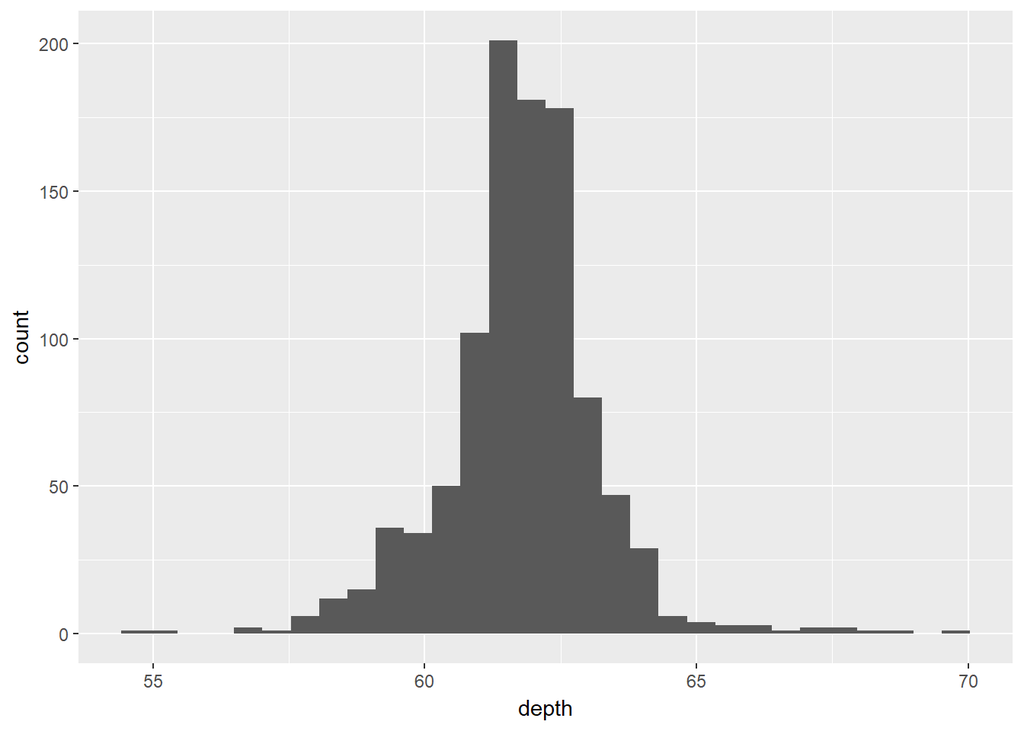

```r
ggplot(dsmall, aes(x=depth)) + geom_histogram()
```

can control the size of the bins by providing an argument to the histogram layer.

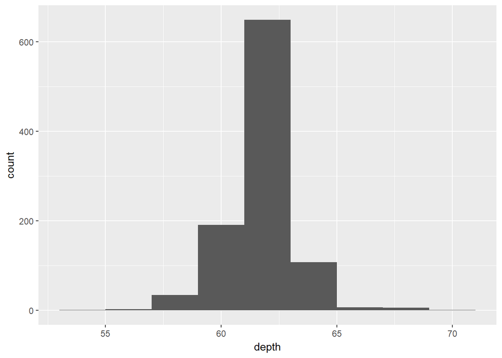

```r
ggplot(dsmall, aes(x=depth)) + geom_histogram(binwidth = 2)
```

Density plot instead

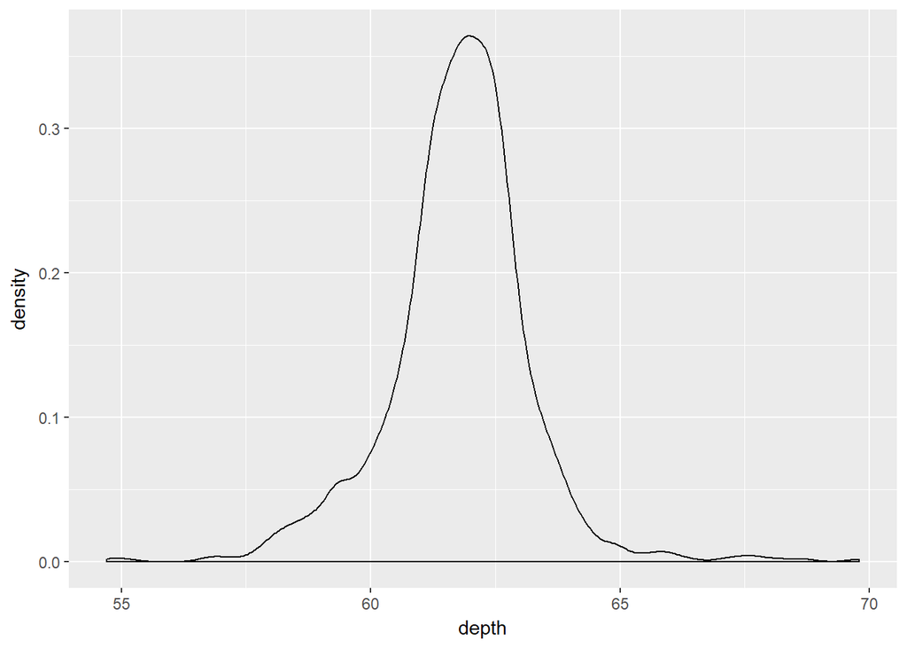

```r
ggplot(dsmall, aes(x=depth)) + geom_density()
```

#### histogram + density

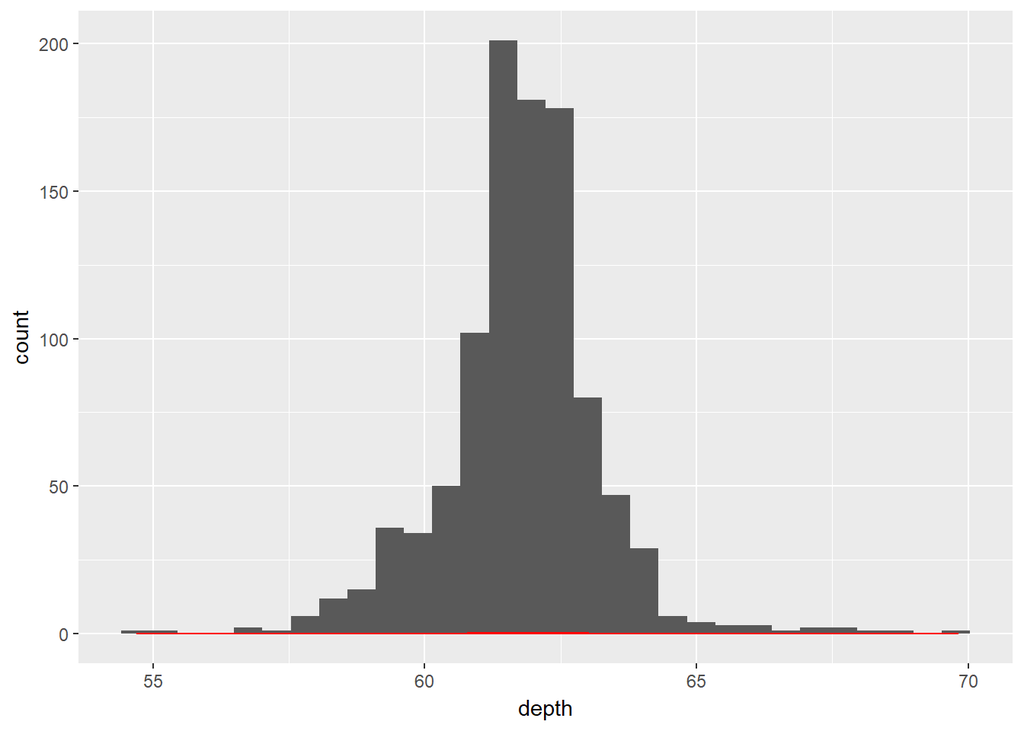

```r
ggplot(dsmall, aes(x=depth)) + geom_histogram() +  geom_density(col="red")
```

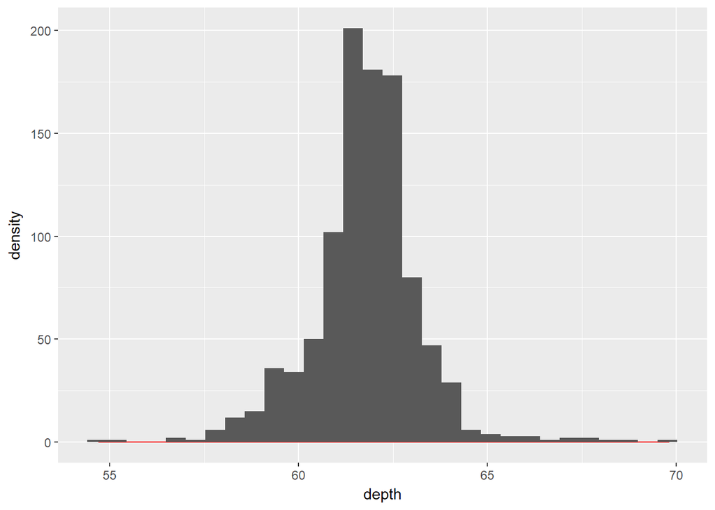

```r
ggplot(dsmall, aes(x=depth)) + geom_density(col="red") +  geom_histogram()
```

- we have to specify that the histogram layer has a different `aes`tetic structure.
- We tell the histogram layer to plot the density of the data on the y axis, not the count.
- the `..` double dots around `density` indicate this is a variable that is internally calculated.

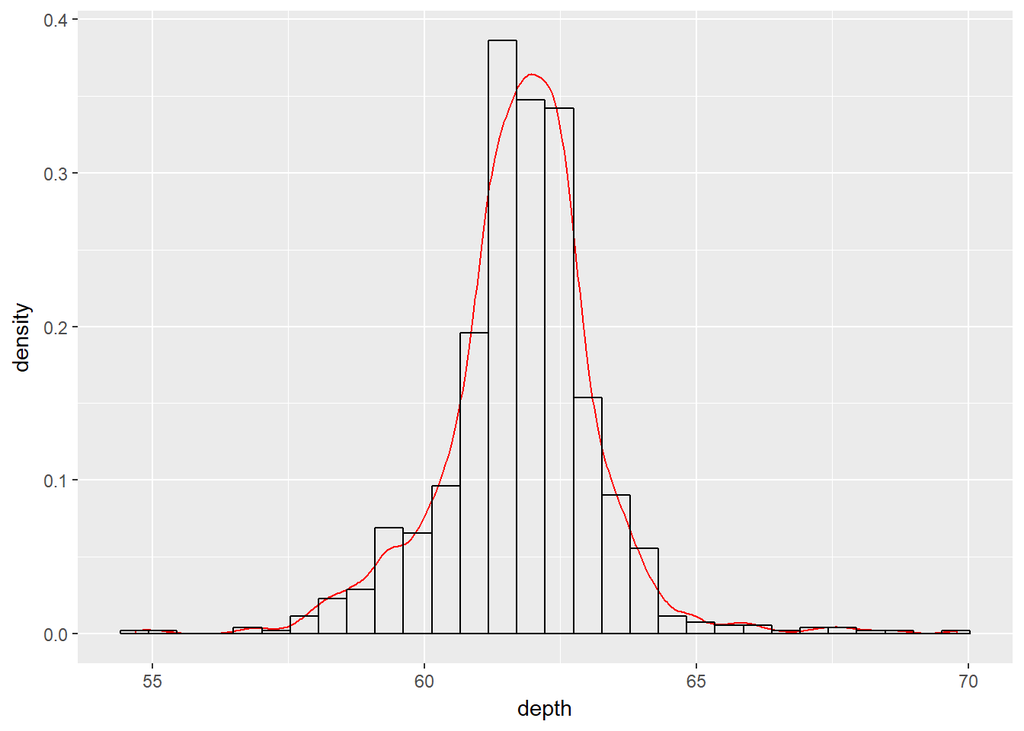

```r
ggplot(dsmall, aes(x=depth)) + geom_density(col="red") +
  geom_histogram(aes(y=..density..), colour="black", fill=NA)
```

#### boxplots

For one variable - easier done in base graphics

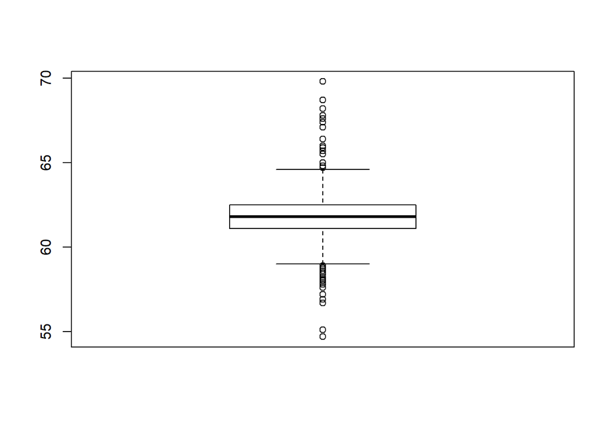

```r
boxplot(dsmall$depth)
```

add some critical information so we know what this plot is about. And let’s turn this horizontal

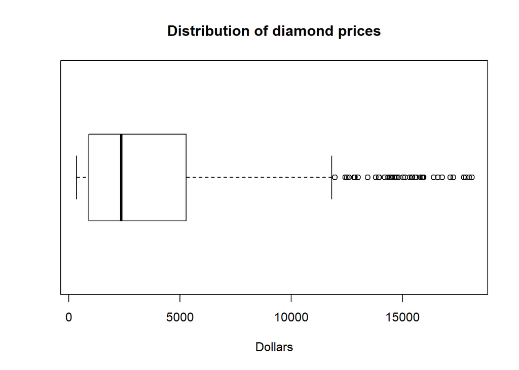

```r
boxplot(dsmall$price, horizontal = TRUE, main="Distribution of diamond prices", xlab="Dollars")
```

# bivariate - two variables

## Cat ~ cat

Two way table

1. Frequency table

```r
table(dsmall$cut, dsmall$color)
```

```
##
##              D  E  F  G  H  I  J
##   Fair       4  5  4  3 10  1  0
##   Good      13  6 19 16 10 13  6
##   Very Good 30 60 37 50 26 18  5
##   Premium   39 42 40 55 46 40 15
##   Ideal     63 69 52 77 65 40 21
```

2. Cell proportions – denominator is ALL data

Wrap `prop.table()` around the `table()` function

```r
prop.table(
  table(dsmall$cut, dsmall$color)
)
```

```
##
##                 D     E     F     G     H     I     J
##   Fair      0.004 0.005 0.004 0.003 0.010 0.001 0.000
##   Good      0.013 0.006 0.019 0.016 0.010 0.013 0.006
##   Very Good 0.030 0.060 0.037 0.050 0.026 0.018 0.005
##   Premium   0.039 0.042 0.040 0.055 0.046 0.040 0.015
##   Ideal     0.063 0.069 0.052 0.077 0.065 0.040 0.021
```

```r
#prop.table(table(dsmall$cut, dsmall$color)) # same as above
```

3. Row proportions – what % of the columns is within each row

matricies are indexed by [row, column] * margin 1 is rows * margin 2 is columns

Think of it as what dimesion (row or column) do you want to add to 100%? * ROWS are your denominator

```r
prop.table(table(dsmall$cut, dsmall$color), margin=1)
```

```
##
##                      D          E          F          G          H
##   Fair      0.14814815 0.18518519 0.14814815 0.11111111 0.37037037
##   Good      0.15662651 0.07228916 0.22891566 0.19277108 0.12048193
##   Very Good 0.13274336 0.26548673 0.16371681 0.22123894 0.11504425
##   Premium   0.14079422 0.15162455 0.14440433 0.19855596 0.16606498
##   Ideal     0.16279070 0.17829457 0.13436693 0.19896641 0.16795866
##
##                      I          J
##   Fair      0.03703704 0.00000000
##   Good      0.15662651 0.07228916
##   Very Good 0.07964602 0.02212389
##   Premium   0.14440433 0.05415162
##   Ideal     0.10335917 0.05426357
```

- 16.3 % OF ideal diamonds are of color D
4. Column proportions
- columns will add up to 100
- margin = 2

```r
prop.table(table(dsmall$cut, dsmall$color), margin=2)
```

```
##
##                       D           E           F           G           H
##   Fair      0.026845638 0.027472527 0.026315789 0.014925373 0.063694268
##   Good      0.087248322 0.032967033 0.125000000 0.079601990 0.063694268
##   Very Good 0.201342282 0.329670330 0.243421053 0.248756219 0.165605096
##   Premium   0.261744966 0.230769231 0.263157895 0.273631841 0.292993631
##   Ideal     0.422818792 0.379120879 0.342105263 0.383084577 0.414012739
##
##                       I           J
##   Fair      0.008928571 0.000000000
##   Good      0.116071429 0.127659574
##   Very Good 0.160714286 0.106382979
##   Premium   0.357142857 0.319148936
##   Ideal     0.357142857 0.446808511
```

- 42.3 % OF D color diamonds are of Ideal cut

> rounding digits

wrap this whole thing in the `round()` function to round digits.

```r
round(
  prop.table(
      table(dsmall$cut, dsmall$color)
  , margin=2)
,3)
```

```
##
##                 D     E     F     G     H     I     J
##   Fair      0.027 0.027 0.026 0.015 0.064 0.009 0.000
##   Good      0.087 0.033 0.125 0.080 0.064 0.116 0.128
##   Very Good 0.201 0.330 0.243 0.249 0.166 0.161 0.106
##   Premium   0.262 0.231 0.263 0.274 0.293 0.357 0.319
##   Ideal     0.423 0.379 0.342 0.383 0.414 0.357 0.447
```

### bar charts!

- the second variable is included as a `fill` color

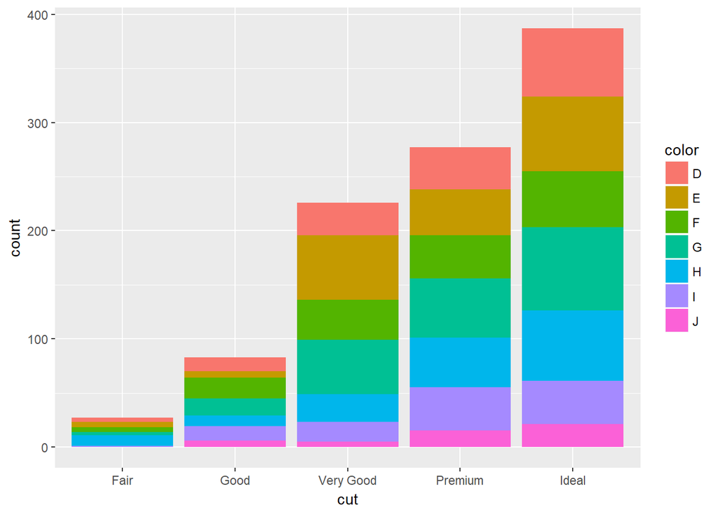

```r
ggplot(dsmall, aes(x=cut, fill=color)) + geom_bar()
```

- default is a stacked bar chart – kinda hard to read
- alternative is to create a side by side bar chart – add a `position` argument to the `geom_bar()` layer

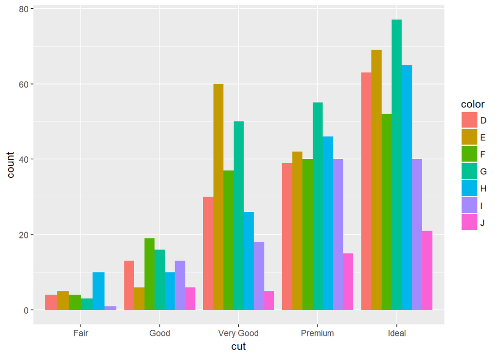

```r
ggplot(dsmall, aes(x=cut, fill=color)) + geom_bar(position = "dodge")
```

- this demonstrates comparing color within cut.
- how can we change the above code to commpare CUT within Color?

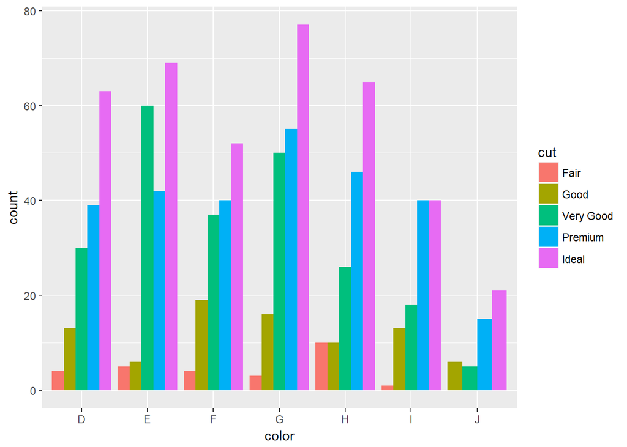

```r
ggplot(dsmall, aes(x=color, fill=cut)) + geom_bar(position = "dodge")
```

## Continuous vs continuous

- now we define what variable is on the x AND what variable is on the y axis
- add a trend line using `geom_smooth()`

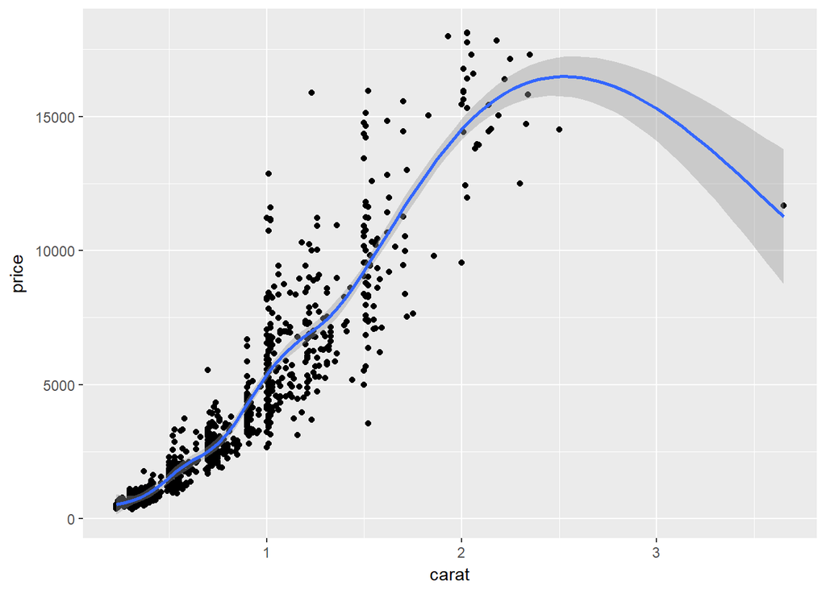

```r
ggplot(dsmall, aes(x=carat, y=price)) + geom_point() + geom_smooth()
```

- other options for this trend line include:

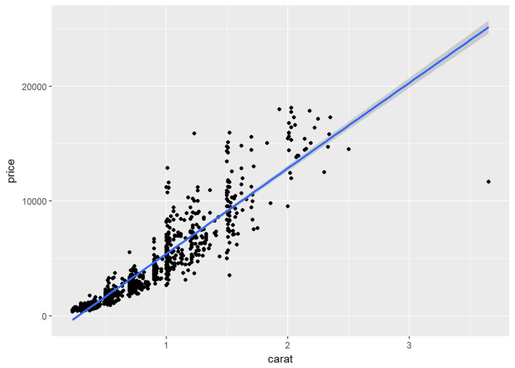

```r
# 1 fitting a linear model line
ggplot(dsmall, aes(x=carat, y=price)) + geom_point() + geom_smooth(method="lm")
```

why not just use `geom_line()` – this connects the dots directly

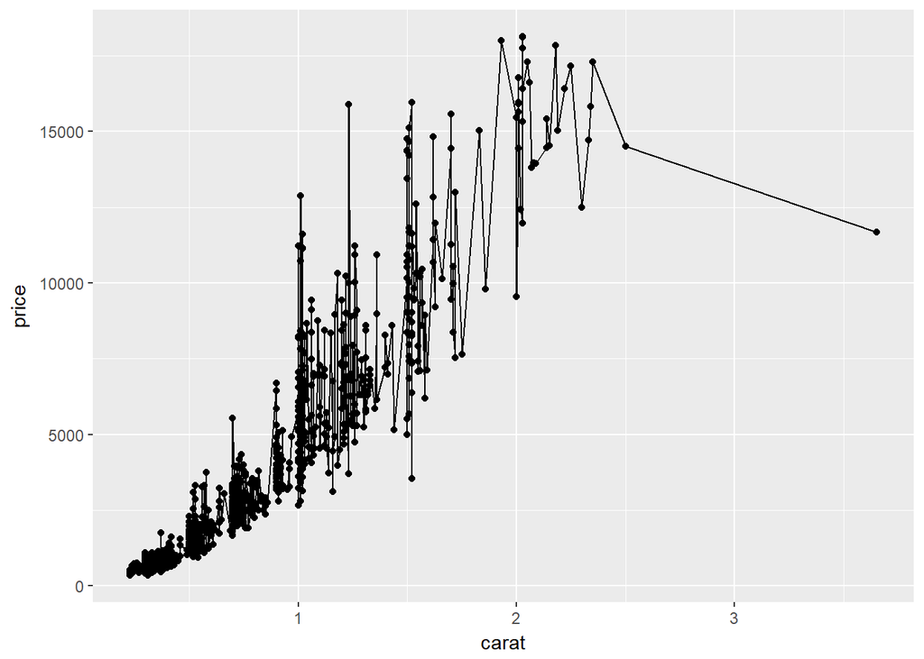

```r
ggplot(dsmall, aes(x=carat, y=price)) + geom_point() + geom_line()
```

What happens if you remove the `geom_point()` layer? –

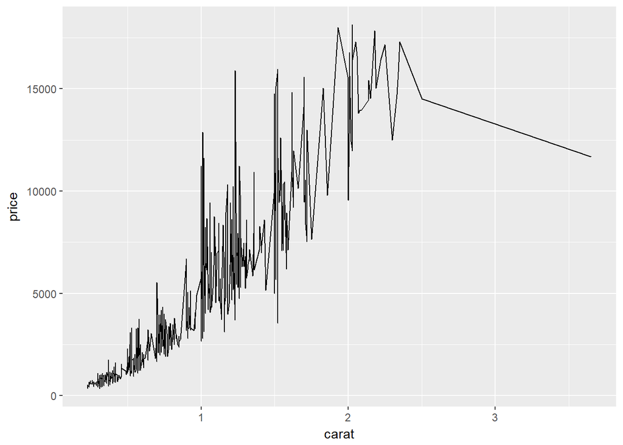

```r
ggplot(dsmall, aes(x=carat, y=price)) + geom_line()
```

## cat ~ quanti

- grouped boxplots
  - y axis here is our continuous variable
  - x is the categorical

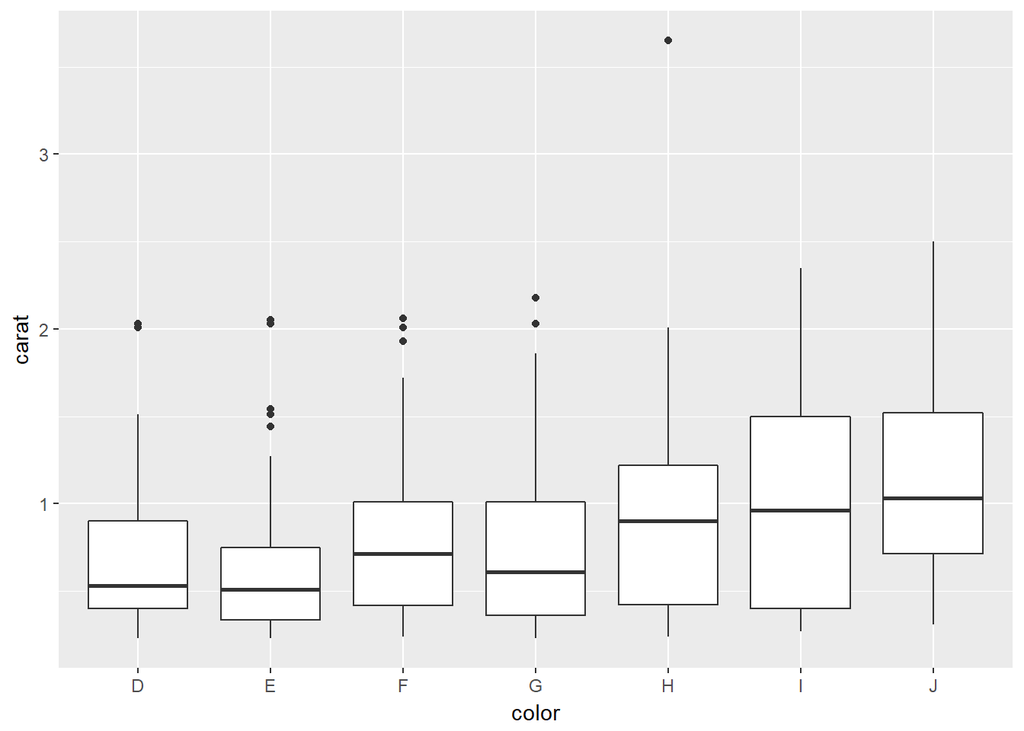

```r
ggplot(dsmall, aes(x=color, y=carat)) + geom_boxplot()
```

what if I want horizontal? can i switch x & y?

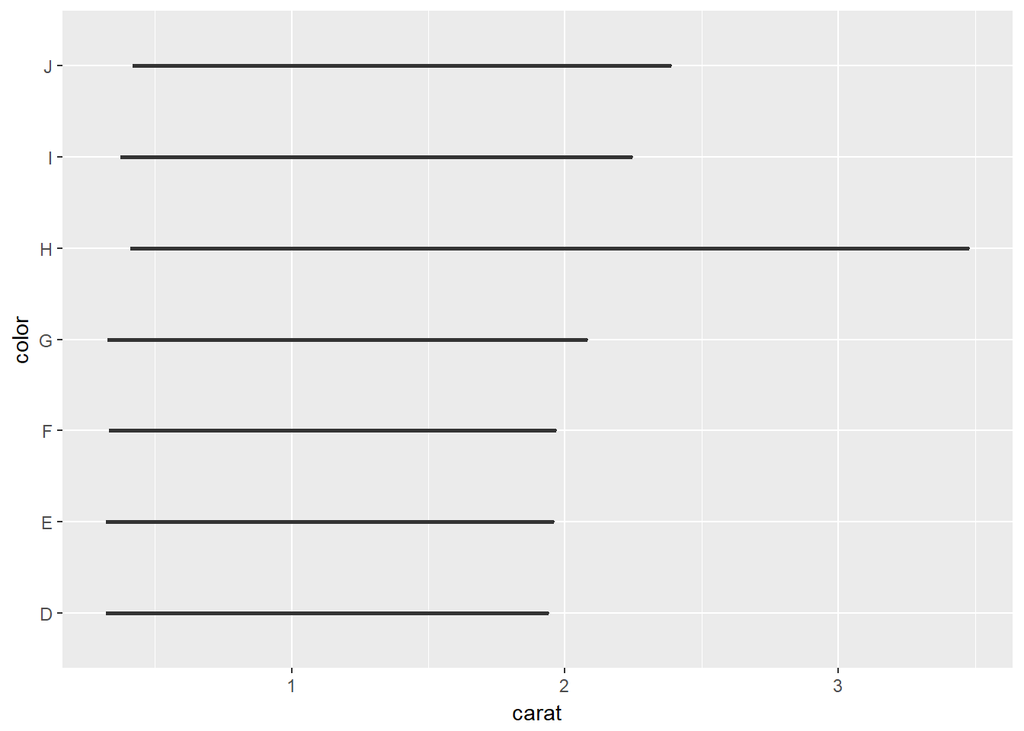

```r
ggplot(dsmall, aes(y=color, x=carat)) + geom_boxplot()
```

This method didn’t work!

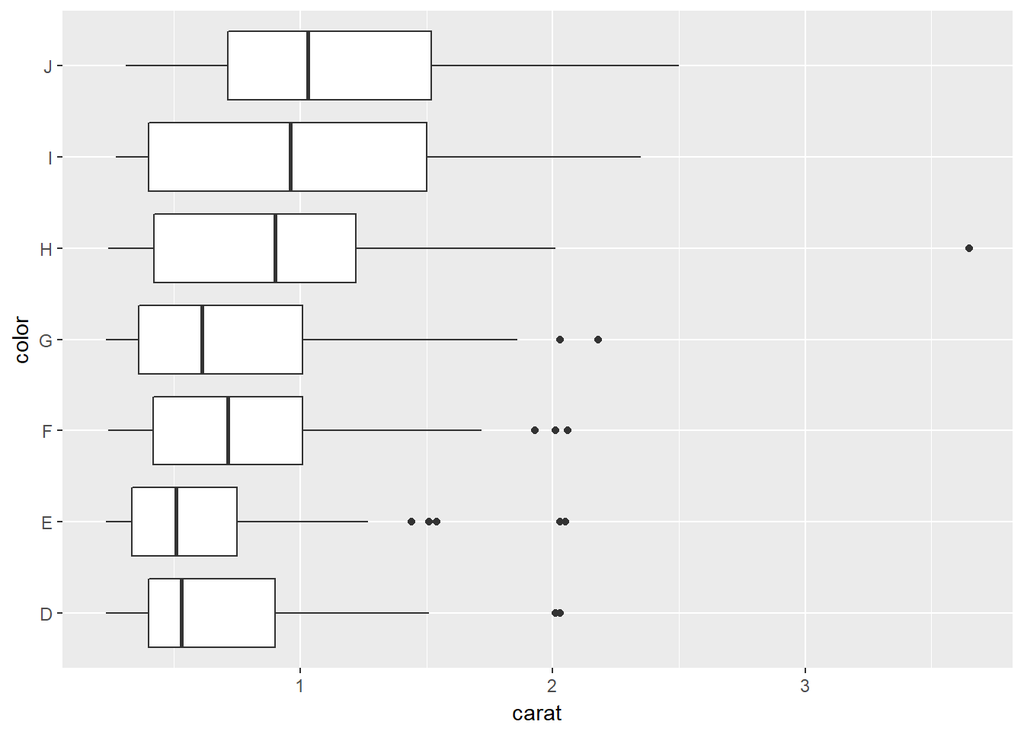

```r
ggplot(dsmall, aes(x=color, y=carat)) + geom_boxplot() + coord_flip()
```

- lets add some colors!
- color by categorical variable

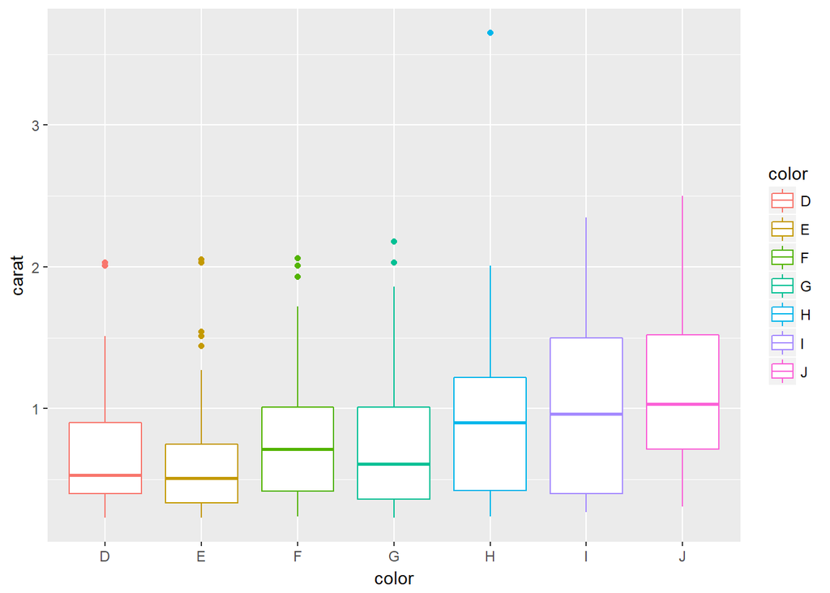

```r
ggplot(dsmall, aes(x=color, y=carat, col=color)) + geom_boxplot()
```

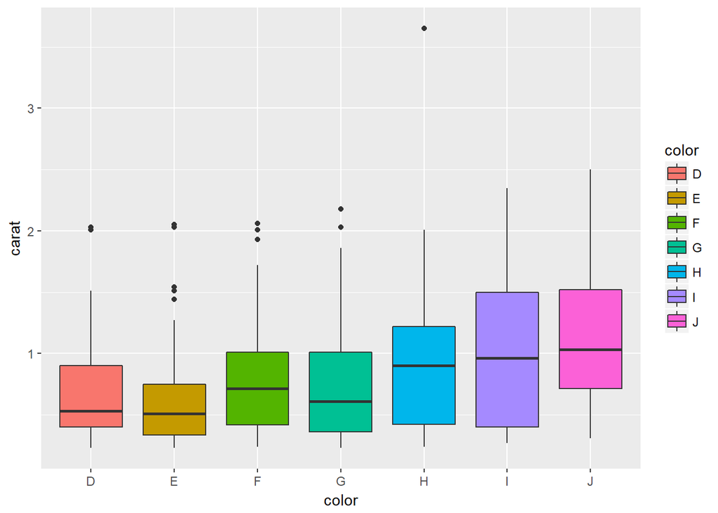

```r
ggplot(dsmall, aes(x=color, y=carat, fill=color)) + geom_boxplot()
```

- now add a violin

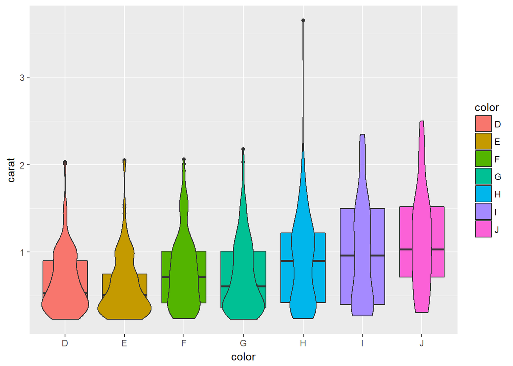

```r
# boxplots first, add violin on top - hides the boxes
ggplot(dsmall, aes(x=color, y=carat, fill=color)) + geom_boxplot() + geom_violin()
```

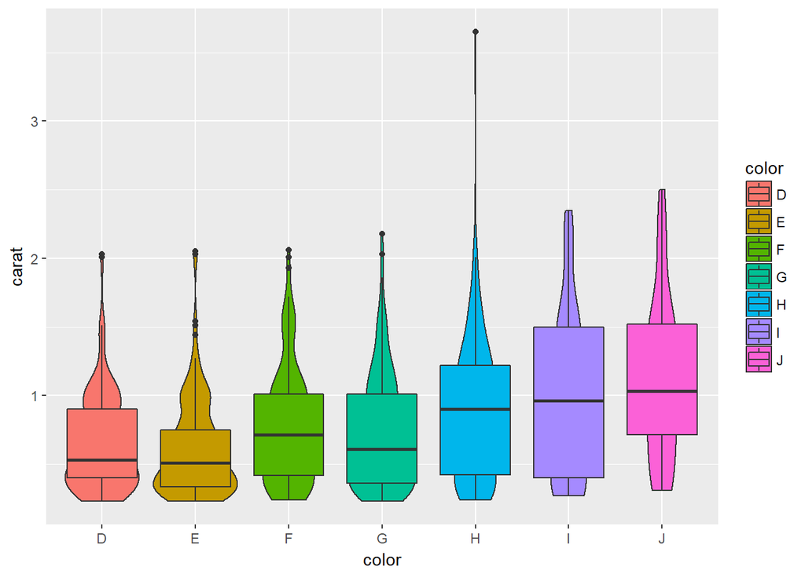

```r
# violins first
ggplot(dsmall, aes(x=color, y=carat, fill=color)) + geom_violin() + geom_boxplot()
```

Neither option is pretty good. so we’ll clean it up by controlling the transparency using `alpha`, which ranges from 0 -1, and also shrink the width of the boxes.

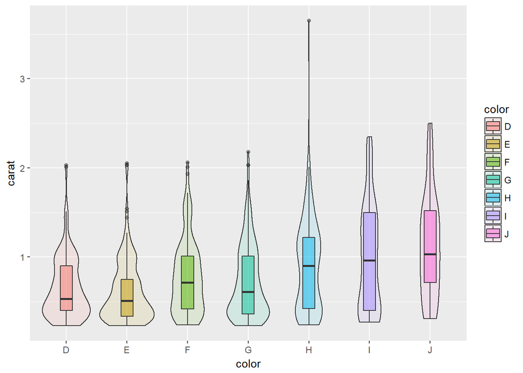

```r
ggplot(dsmall, aes(x=color, y=carat, fill=color)) +
        geom_violin(alpha=.1) +
        geom_boxplot(alpha=.5, width=.2)
```

### grouped histograms

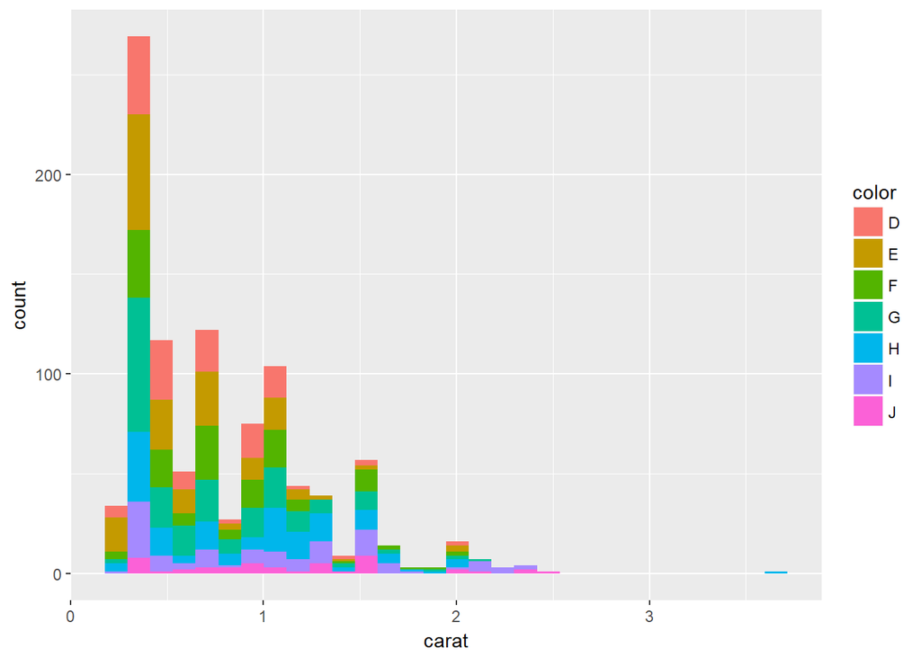

```r
ggplot(dsmall, aes(x=carat, fill=color)) + geom_histogram()
```

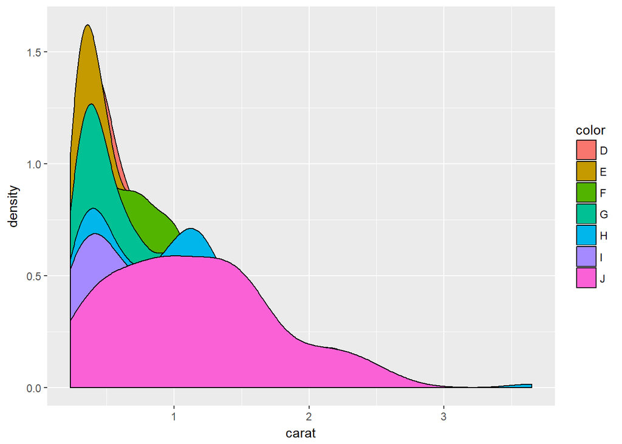

```r
ggplot(dsmall, aes(x=carat, fill=color)) + geom_density()
```

not readable due to overlap

- remedy by
- change alpha /transparency
- use color instead of fill

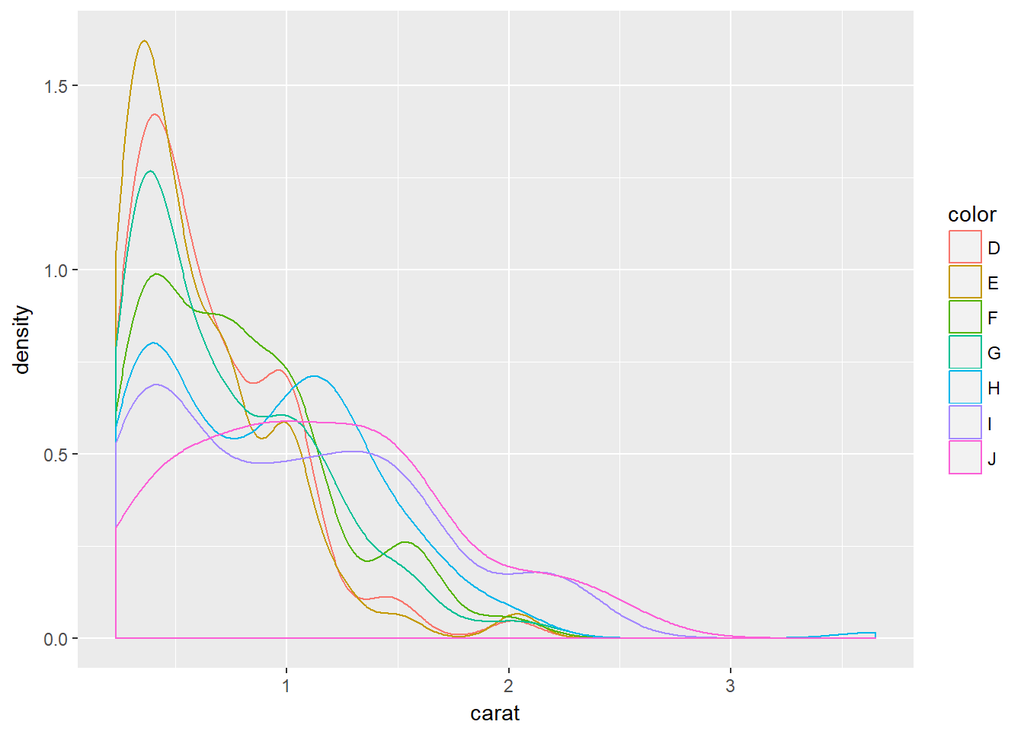

```r
ggplot(dsmall, aes(x=carat, col=color)) + geom_density()
```

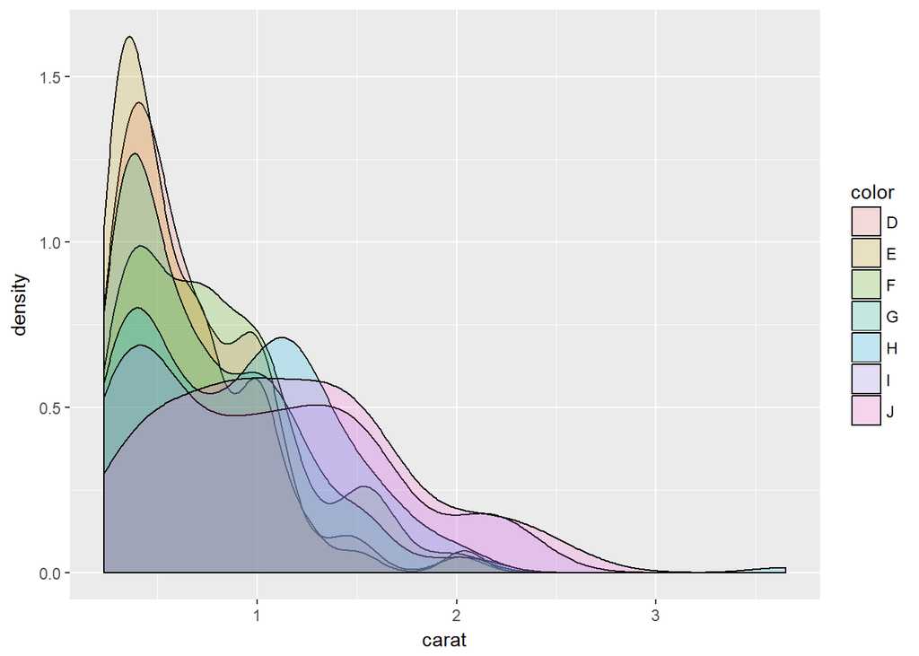

```r
ggplot(dsmall, aes(x=carat, fill=color)) + geom_density(alpha=.2)
```

> interlude : putting plots side by side

Plots are just objects. so save them as objects. Use the `grid.arrange` function inside the `gridExtra` package to arrange the plots. - first plot a, then b, in 2 columns

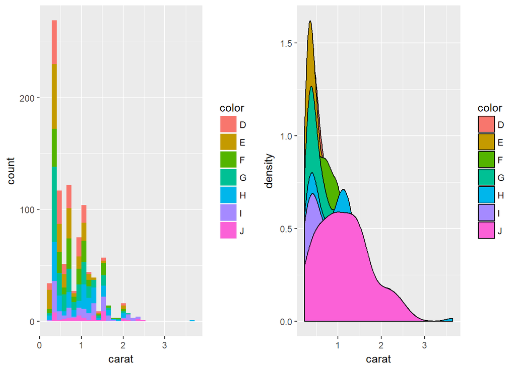

```r
library(gridExtra)
a <- ggplot(dsmall, aes(x=carat, fill=color)) + geom_histogram()
b <- ggplot(dsmall, aes(x=carat, fill=color)) + geom_density()
grid.arrange(a,b, ncol=2)
```

> other interlude: what is that notation gridExtra::grid.arrange

If you want to call a function without having to load the entire package.

package::function

- useful especially when using dplyr – the `filter` and `select` , `recode` functions overlap/conflict with same named functions in other packages.
- red flag warning: if you’re convinced you loaded a library for a function, but R keeps saying “function does not exist?” – likely a package conflict.